# Analyzing RNA-seq Data with the FPKM Package

Veronica Gosnell

# Overview

The `FPKM` package provides utilities for processing and visualizing RNA-seq data using **FPKM** (**F**ragments **P**er **K**ilobase of transcript per **M**illion mapped reads) normalization.

**FPKM** is a commonly used method to normalize RNA-seq data, enabling the comparison of $\underline{gene\space expression}$ levels between samples. It adjusts for both the *length* of the gene and the *total number of reads* in the sample, offering a way to account for **variations** in sequencing depth and gene length. This allows for more accurate comparison of expression levels across genes and samples in RNA-seq experiments.

# Introduction

This vignette demonstrates how to use the `FPKM` package to analyze RNA-seq data. We will cover several common tasks, such as filtering low-expression genes, normalizing for gene length and sequencing depth, and generating key visualizations such as heatmaps, boxplots, and Principal Component Analysis (PCA).

## Installation

First, make sure you have the `FPKM` package installed. You can install it from GitHub with the following command:

```r
devtools::install_github("vsgosnell/FPKM")
```

# Loading the Package

## Once installed, load the package and required libraries for this tutorial:

```r
library(FPKM)
library(ggplot2)
library(readr)
```

# Loading Data

The first step in RNA-seq analysis is to load your data. We will load the RNA-seq data from the `vehicle_drug_feature_counts.txt` file. The file contains read counts for multiple samples, including vehicle (*control*) and drug treatment conditions.

Download: vehicle_drug_feature_counts.txt

```r
# Load data from featureCounts output
vehicle_drug_data_path <- "/Users/veronicagosnell/Desktop/R/FPKM/inst/extdata/vehicle_drug_feature_counts.txt"

# Read using readr::read_tsv and skip comment lines
vehicle_drug_data <- readr::read_tsv(vehicle_drug_data_path, comment = "#")

# Rename length column if needed
if ("length" %in% colnames(vehicle_drug_data)) {
  colnames(vehicle_drug_data)[colnames(vehicle_drug_data) == "length"] <- "Length"
}

stopifnot("Length" %in% colnames(vehicle_drug_data))
stopifnot(all(sapply(vehicle_drug_data[, grep("\\.bam$", colnames(vehicle_drug_data))], is.numeric)))
stopifnot(nrow(vehicle_drug_data) == length(vehicle_drug_data$Length))
```

### View the first few rows to confirm it loaded correctly

```r
head(vehicle_drug_data)
```

```
## # A tibble: 6 × 10
##   Geneid     Chr    Start    End Strand Length vehicle_rep1.bam vehicle_rep2.bam
##   <chr>      <chr>  <dbl>  <dbl> <chr>   <dbl>            <dbl>            <dbl>
## 1 PF3D7_062… Pf3D… 8.77e5 8.77e5 -         620                0                7
## 2 PF3D7_131… Pf3D… 6.25e5 6.26e5 +        1227               68               54
## 3 PF3D7_020… Pf3D… 3.88e5 3.91e5 -        2188              305              286
## 4 PF3D7_114… Pf3D… 1.69e6 1.69e6 -        1241                8               20
## 5 PF3D7_050… Pf3D… 2.98e5 3.01e5 -        2310               43               45
## 6 PF3D7_080… Pf3D… 3.26e5 3.30e5 -        3790               81               62
## # ℹ 2 more variables: drug_rep1.bam <dbl>, drug_rep2.bam <dbl>
```

### This dataset contains the following columns:

- **GeneID**: The gene identifier
- **Chr**: The chromosome
- **Start**: The start position of the gene
- **End**: The end position of the gene
- **Strand**: The positive or negative strand of the gene
- **Length**: The length of the gene
- **vehicle_rep1, vehicle_rep2, drug_rep1, drug_rep2**:
  - The read counts for different replicates of the vehicle and drug treatments

# Calculating FPKM Values

Once the data is loaded, you can compute **FPKM values**. This method is used to normalize gene expression data in RNA-seq experiments by accounting for *sequencing depth* and *gene length*.

The `calculate_fpkm()` function calculates the **FPKM values** from *read counts* and *gene lengths*.

```r
# Identify sample columns
sample_columns <- grep("\\.bam$", colnames(vehicle_drug_data), value = TRUE)

# Calculate FPKM
fpkm_values <- calculate_fpkm(vehicle_drug_data, count_cols = sample_columns)

# Preview
head(fpkm_values)
```

```
##   vehicle_rep1.bam vehicle_rep2.bam drug_rep1.bam drug_rep2.bam
## 1          0.00000         7.218673      3.383245      4.058606
## 2         36.17499        28.138454      7.408028     12.817521
## 3         90.99061        83.573723     66.469108     59.515710
## 4          4.20787        10.304081      6.197617      1.520751
## 5         12.15068        12.455225     15.436969     11.710220
## 6         13.95050        10.459322     10.515731     10.955024
```

### Results:

- This function returns a data frame containing the **FPKM values** for each gene across all samples.
- **FPKM** normalizes expression levels by both gene length (longer genes tend to have more reads) and library size (total read count per sample). This makes expression levels more **comparable** across genes and samples.

# Filtering Low Expression Genes

To improve the accuracy of downstream analysis, we can filter out genes with **low expression** levels.

The `filter_low_expression()` function allows us to filter genes based on a threshold **FPKM** value.

```r
# Filter out low-expression genes (e.g., average FPKM < 1)
filtered_data <- filter_low_expression(fpkm_values, threshold = 1)
```

### Why filter?

- Genes with consistently **low expression** can introduce *noise*.
- Filtering improves downstream analyses like clustering, PCA, and differential expression.

# Visualizing Gene Expression

## Heatmap of Gene Expression

We can create a heatmap to visualize the **gene expression patterns** of the most variable genes across the samples using the `plot_expression_heatmap()` function.

#### **What this does:**

1. **Compute variance** for each gene (row) across your samples
2. **Order** genes by descending variance and pick the top `N`
3. **Subset** your *filtered* FPKM matrix to those genes
4. **Center & scale** each row so differences are on the same scale
5. **Plot** with `pheatmap`, showing just those top `N` genes

$\underline{You\space can\space adjust:}$

- `N` (e.g. 25, 50, 200)
- `show_rownames = TRUE` if you want to see **gene IDs**
- `scale = "row"` inside `pheatmap()` instead of *manually* scaling

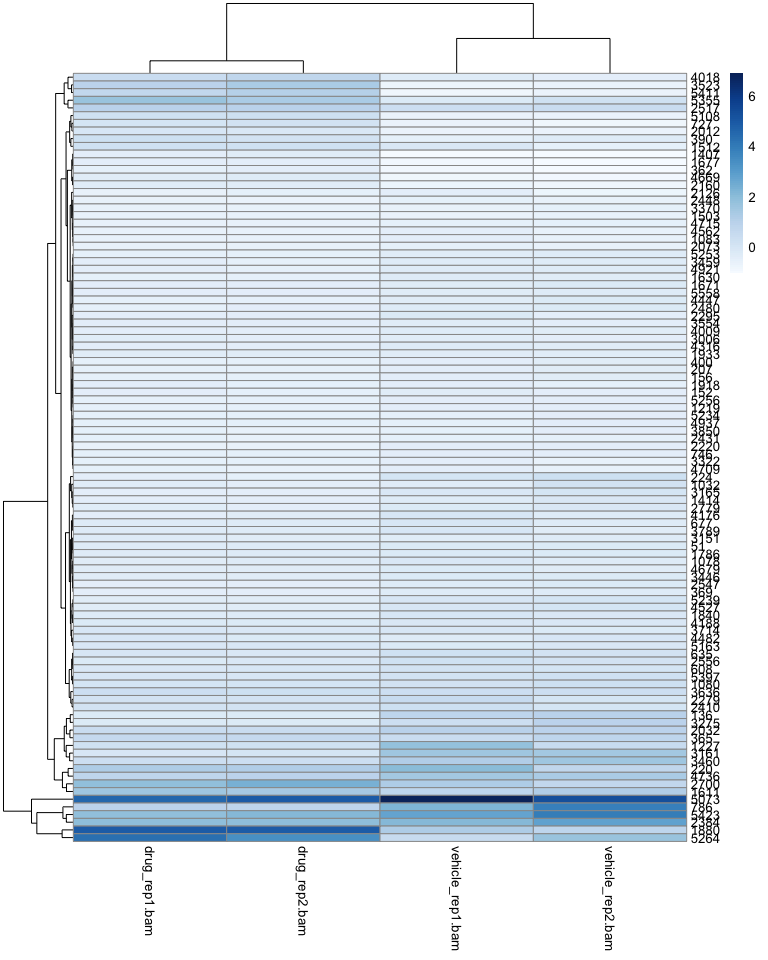

```r
plot_expression_heatmap(filtered_data, top_n = 100)
```

### Results:

- **Rows** = genes
- **Columns** = samples
- **Color** changes indicate relative *expression differences*
- $\underline{Clustering}$ helps identify patterns of co-expression and sample similarity

## Boxplot of FPKM Distribution

A boxplot can be helpful to visualize the distribution of **gene expression** across samples.

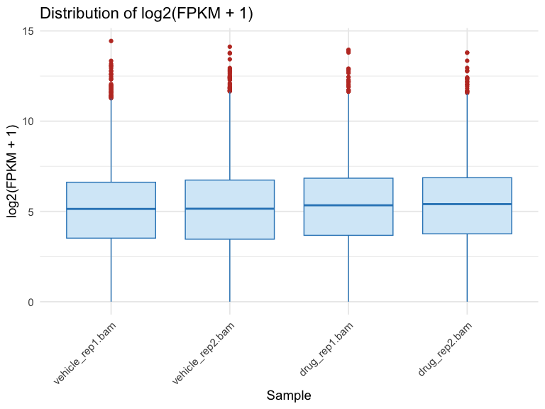

```r
plot_fpkm_boxplot(filtered_data)
```

### Results:

- Boxplots show **median**, **quartiles**, and **outliers** of log-transformed `FPKM` values
  - Helps assess sample distribution and variability
- RNA-seq data commonly contains lots of genes with 0 or *near-zero* expression
  - These low values create a long lower tail, and the few highly expressed genes pull the median and upper quartile upward
  - So when you plot individual points (like geom_jitter()), they tend to bunch up at the **upper end** of the visible range (i.e., the *top* whisker)
  - This can be adjusted according to your needs

## Distribution of FPKM Values

To assess the **overall distribution** of expression levels, we can plot the distribution of `FPKM` values.

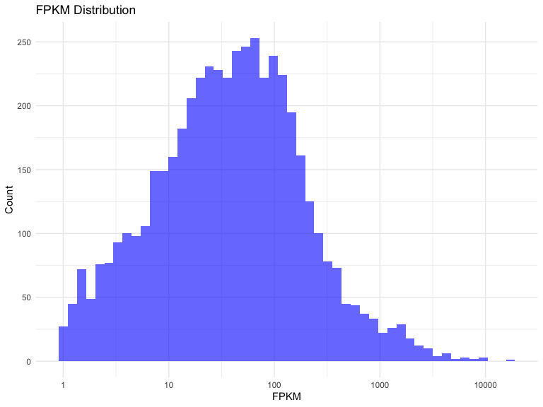

```r
filtered_data$FPKM <- rowMeans(filtered_data)
plot_fpkm_distribution(filtered_data$FPKM)
```

# Principal Component Analysis (PCA)

To explore the overall variation in the data, we can perform **Principal Component Analysis (PCA)** on the `FPKM` values.

**PCA** is used to reduce *dimensionality* and visualize major **patterns** in gene expression data that capture the most important variation across samples. This enables visualization of groupings, patterns, and outliers in a simple 2D plot.

## Quick PCA Visualization

The `FPKM` package provides a convenient wrapper function, `plot_pca_fpkm()`, that performs **log-transformation**, **PCA**, and **plotting** in one step.

It displays the *first two* principal components, which together explain most of the variance in the data.

Below, shows both this quick-use function and a step-by-step breakdown of how **PCA** is performed on the `FPKM` dataset.

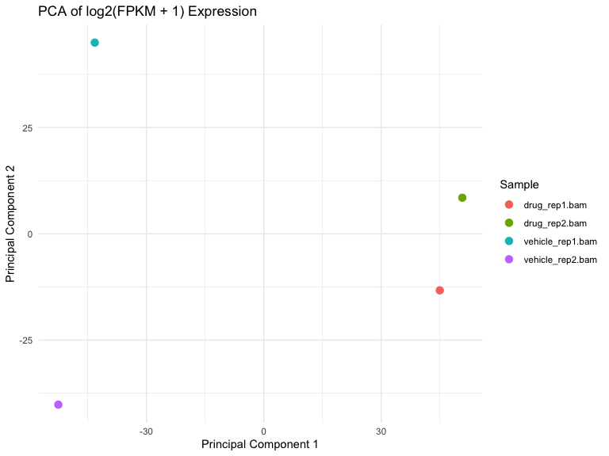

```r
plot_pca_fpkm(filtered_data)
```

### Results:

- Can reveal batch effects, sample outliers, or treatment separation
- Samples that cluster together have **similar expression profiles**
  - If treated and untreated samples cluster separately along PC1 or PC2:
    - This suggests that treatment strongly *influences* gene expression
- If samples from the same group cluster tightly:
  - Indicates *reproducibility* within conditions
- Outliers or overlapping clusters might indicate **batch effects** or **subtle expression changes**

## PCA: Step-by-Step Breakdown

While the `plot_pca_fpkm()` function provides a fast and convenient way to visualize **PCA** results, this section walks through the process step-by-step. This approach is useful for users who want to customize the analysis or better understand how **PCA** is computed and interpreted from their `FPKM` data.

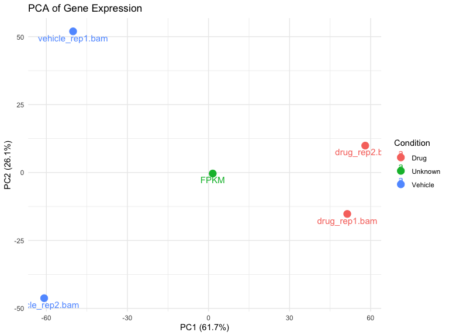

```r
# Log-transform filtered data
log_fpkm <- log2(filtered_data + 1)

# transpose the matrix
pca_input <- t(log_fpkm)

# Run PCA
pca_result <- prcomp(pca_input, scale. = TRUE)

# Calculate percentage of variance explained by PC1 and PC2
pve <- round(100 * summary(pca_result)$importance[2, 1:2], 1)

# Create PCA data frame for plotting
pca_df <- as.data.frame(pca_result$x)
pca_df$Sample <- rownames(pca_df)

# Assign conditions based on sample names
pca_df$Condition <- ifelse(grepl("vehicle", pca_df$Sample, ignore.case = TRUE), "Vehicle", ifelse(grepl("drug", pca_df$Sample, ignore.case = TRUE), "Drug", "Unknown"))

# load the ggplot library
library(ggplot2)

# Plot PCA with color by condition
ggplot(pca_df, aes(x = PC1, y = PC2, color = Condition, label = Sample)) +
  geom_point(size = 4) +
  geom_text(vjust = 1.5, size = 4) +
  labs(
    title = "PCA of Gene Expression",
    x = paste0("PC1 (", pve[1], "%)"),
    y = paste0("PC2 (", pve[2], "%)")
  ) +
  theme_minimal()
```

### Results:

- Implements the full PCA pipeline inline
- Explains and displays PC1/PC2 variance
- PC1 and PC2 capture the **most significant sources of variation** in the dataset
- Samples clustering together on the PCA plot are more similar in expression profiles
- This plot helps identify batch effects, outliers, or biological groupings

### Customizing PCA plot:

The plot can be modified in several ways depending on your needs:

- Add **color** or **shape** by *condition* (i.e., treatment vs control) to visually distinguish biological groups
- Change **scale. argument** to normalize variance across genes
- Use **other Principle Components** (i.e., PC3, PC4, etc.) to analyze more subtle variation
- Add **confidence ellipses** to show group dispersion using stat_ellipse()

# Correlation Between Samples

We can also check the correlation between samples using the `plot_sample_correlation()` function.

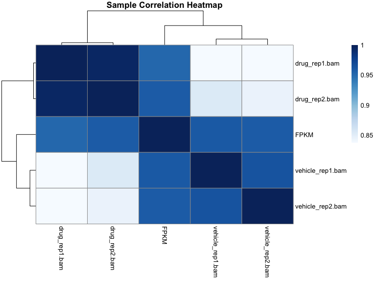

```r
plot_sample_correlation(filtered_data)
```

### Results:

- Highly correlated samples should cluster *together*
- Useful **quality control** step to confirm experimental replicates behave similarly

# Conclusion

This vignette demonstrated how to use the `FPKM` package for RNA-seq data analysis. We successfully:

- Loaded a dataset
- Calculated **FPKM values**
- Filtered low-expression genes
- Visualized the data using:
  - Heatmaps
  - Boxplot
  - PCA

These steps form a robust pipeline for analyzing and interpreting RNA-seq experiments and provide a solid foundation for further exploration of gene expression data.

For advanced usage or more information on the FPKM package, refer to the package documentation and explore additional helper functions.